# HUMAN ACTIVITY RECOGNITION: WEIGHT LIFTING EXERCISE CLASSIFICATION AND PREDICTION REPORT

Leopold Hillah

Sunday, September 21st, 2014

## SYNOPSIS

This analysis is about classifying how well weight lifters performed exercises and build a model to predict future outcomes based on a number of predictor variables. The data was generated from accelerometers on the belt, forearm, arm, and dumbell of 6 participants. The data for this project came from this http://groupware.les.inf.puc-rio.br/har.

The goal of this project is to predict the manner in which participants did the exercise. This is represented by the “classe” variable in the training set. The model prediction model built will be used to predict 20 different test cases.

## DATA PROCESSING

### 1. RAW DATA

The raw data for this project are csv files available at the following locations: - [Training data: https://d396qusza40orc.cloudfront.net/predmachlearn/pml-training.csv](https://d396qusza40orc.cloudfront.net/predmachlearn/pml-training.csv) - [Testing data: https://d396qusza40orc.cloudfront.net/predmachlearn/pml-testing.csv](https://d396qusza40orc.cloudfront.net/predmachlearn/pml-testing.csv)

### 2. DATA LOADING & PRE-PROCESSING

The data load assumes that both csv files were downloaded and stored in the current working directory, whose value can be obtained by the `getwd()` R command. The data is then loaded into various data frames using the `read.scv` R command.

```r
# set global chunk options: images will be 24x10 inches
knitr::opts_chunk$set(cache.lazy=FALSE, echo=TRUE, message=FALSE, fig.width=24, fig.height=10)
```

### Setting up the R environment

```r
# Clearing the cache
rm(list = ls())

# Loading required libraries
if ((!require(e1071)) | (!require(randomForest)) | (!require(caret))) install.packages('e1071', 'randomForest', 'caret')
```

### Loading and preprocessing the data

```r
# Set working directoy here for csv file loading
filepath <- getwd()

# Load csv data data frames
hartrain <- read.csv(paste(filepath, "pml-training.csv", sep="/"), na.strings=c("NA",""), strip.white=TRUE)
hartest <- read.csv(paste(filepath, "pml-testing.csv", sep="/"), na.strings=c("NA",""), strip.white=TRUE)
# str(hartrain)
```

Once the data is loaded, it is important to explore the main fields of interest in the training set needed to answer the questions under investigation. But some initial cleaning needs to be done first. First, columns with 5% or more null values are removed from the data frame. **From 160 columns, the total number of columns got reduced to 60.**

```r
# Data Cleanup - Remove columns with 5% or more NA values from training set
# From 160 columns, we are left with only 60

hartrain <- hartrain[,colSums(is.na(hartrain))< 0.05 * nrow(hartrain)]
(ncols <- ncol(hartrain))
```

```
## [1] 60
```

The next step consists in the exploration of remaining columns to identified possible columns to remove from the data frame as they might not contribute to final outcome.

```r
# Display storm data and structure
head(hartrain)
```

```
##   X user_name raw_timestamp_part_1 raw_timestamp_part_2   cvtd_timestamp
## 1 1  carlitos           1323084231               788290 05/12/2011 11:23
## 2 2  carlitos           1323084231               808298 05/12/2011 11:23
## 3 3  carlitos           1323084231               820366 05/12/2011 11:23
## 4 4  carlitos           1323084232               120339 05/12/2011 11:23
## 5 5  carlitos           1323084232               196328 05/12/2011 11:23
## 6 6  carlitos           1323084232               304277 05/12/2011 11:23
##   new_window num_window roll_belt pitch_belt yaw_belt total_accel_belt
## 1         no         11      1.41       8.07    -94.4                3
## 2         no         11      1.41       8.07    -94.4                3
## 3         no         11      1.42       8.07    -94.4                3
## 4         no         12      1.48       8.05    -94.4                3
## 5         no         12      1.48       8.07    -94.4                3
## 6         no         12      1.45       8.06    -94.4                3
##   gyros_belt_x gyros_belt_y gyros_belt_z accel_belt_x accel_belt_y
```

[output cut: 76 more lines]

```r
# Removing first 7 columns from the data frame
hartrain <- hartrain[, -(1:7)]
(ncols <- ncol(hartrain))
```

```
## [1] 53
```

The **hartrain** data frame is now made of more relevant columns, whose total is 53. With **classe** column being the predicted outcome, the remaining **52** are the predictor variables.

Next, these 52 columns need to be converted to numeric type in order to avoir any errors during processing.

It is also important to check for any missing values left and replace these using the **bagging imputation** method based on existing data in hartrain data frame.

```r
# Convert all columns to numeric except the last one

hartrain [,-ncols] <- data.frame(sapply(hartrain[,-ncols],as.numeric))

# imput any missing values
if(any(is.na(hartrain))){
        hartrain[,-ncols] <- predict(preProcess(hartrain[,-ncols],method="bagImpute"),hartrain[,-ncols])
}
```

## FEATURE SELECTION

To aid in the selection of relevant features, a near zero variance analysis can help identify zero and near-zero variance predictors. This is accomplished using the `nearZeroVar` R function.

```r
# Perform near zero variance analysis and eliminate all features that have NZV
nZerov <- nearZeroVar(hartrain, saveMetrics = TRUE)
(ncols <- ncol(hartrain))
```

```
## [1] 53
```

```r
nZerov[nZerov[, "zeroVar"] > 0, ]
```

```
## [1] freqRatio     percentUnique zeroVar       nzv
## <0 rows> (or 0-length row.names)
```

```r
nZerov[nZerov[, "zeroVar"]  + nZerov[,"nzv"] > 0, ]
```

```
## [1] freqRatio     percentUnique zeroVar       nzv
## <0 rows> (or 0-length row.names)
```

The result of the analysis shows that there is no zero or near-zero variables. The final list of features can now be saved in the **features** variable for further use on the testing data.

```r
# Save list of retained features for further user with testing set
(features <- names(hartrain))
```

```
##  [1] "roll_belt"            "pitch_belt"           "yaw_belt"
##  [4] "total_accel_belt"     "gyros_belt_x"         "gyros_belt_y"
##  [7] "gyros_belt_z"         "accel_belt_x"         "accel_belt_y"
## [10] "accel_belt_z"         "magnet_belt_x"        "magnet_belt_y"
## [13] "magnet_belt_z"        "roll_arm"             "pitch_arm"
## [16] "yaw_arm"              "total_accel_arm"      "gyros_arm_x"
## [19] "gyros_arm_y"          "gyros_arm_z"          "accel_arm_x"
## [22] "accel_arm_y"          "accel_arm_z"          "magnet_arm_x"
## [25] "magnet_arm_y"         "magnet_arm_z"         "roll_dumbbell"
## [28] "pitch_dumbbell"       "yaw_dumbbell"         "total_accel_dumbbell"
## [31] "gyros_dumbbell_x"     "gyros_dumbbell_y"     "gyros_dumbbell_z"
## [34] "accel_dumbbell_x"     "accel_dumbbell_y"     "accel_dumbbell_z"
## [37] "magnet_dumbbell_x"    "magnet_dumbbell_y"    "magnet_dumbbell_z"
## [40] "roll_forearm"         "pitch_forearm"        "yaw_forearm"
## [43] "total_accel_forearm"  "gyros_forearm_x"      "gyros_forearm_y"
## [46] "gyros_forearm_z"      "accel_forearm_x"      "accel_forearm_y"
## [49] "accel_forearm_z"      "magnet_forearm_x"     "magnet_forearm_y"
## [52] "magnet_forearm_z"     "classe"
```

## DATA PARTITIONING AND MODEL FITTING

### 1. DATA PARTITIONING

Once the list of features of interest is set, the training data set can be further partitioned for cross data validation purposes. Here, 90% of the data willbe kept as training data and 10% to generate the cross validation data once the model is built. For reproducibility, a seed of **1122** will be used.

```r
# Data Partitioning into Training and Cross-Validation using 90/10 proportion

set.seed(1122)
dpTrainIdx <- createDataPartition(hartrain$classe, p=0.90, list = FALSE)
dpTrain <- hartrain[dpTrainIdx,]
dpCrossV <- hartrain[- dpTrainIdx,]
```

### 2. MODEL FITTING

The target model can now be built on the training data set using the **Random Forest** method with a **5-fold cross validation**. This is accomplished using the `train()` function in the **caret** package.

```r
# Fitting model using Random Forest and 5-fold cross-validation
harFit <- train(classe ~ ., data = dpTrain, method = "rf", preProcess = c("center", "scale"), prox = TRUE,
                importance=TRUE, trControl = trainControl(allowParallel = TRUE, method = "cv", number = 5, verboseIter=TRUE))
```

## CROSS VALIDATION AND MODEL EVALUATION

Plotting the data from the model shows accuracy (cross validation) per number of randomly selected predictors. This shows an accuracy between 0.989 and 0.994.

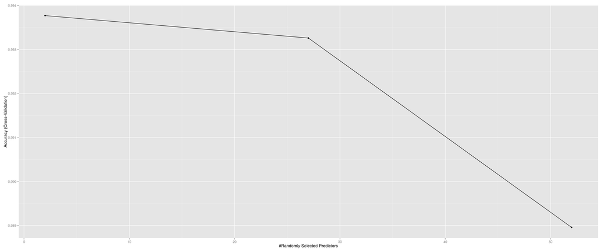

```r
# Plotting
ggplot(harFit)
```

Using the `varImp` function on the model, the most important variables of are shown (top 20).

```r
# Evaluation of variable importance (20 most important variables)
(varHarImp <- varImp(harFit))
```

```
## rf variable importance
##
##   variables are sorted by maximum importance across the classes
##   only 20 most important variables shown (out of 52)
##
##                      A    B    C     D    E
## yaw_belt          88.3 97.7 73.4 100.0 62.3
## roll_belt         72.4 99.8 91.3  83.0 61.6
## pitch_belt        76.5 93.2 76.3  62.0 60.8
## roll_arm          40.3 84.8 73.0  60.8 55.5
## magnet_dumbbell_y 48.6 59.1 77.9  56.7 51.3
## magnet_dumbbell_z 72.0 66.4 75.5  61.4 55.3
## accel_dumbbell_y  51.7 69.5 58.5  60.5 61.5
## magnet_forearm_z  36.7 68.7 50.1  50.7 53.9
## gyros_belt_z      31.2 65.0 50.8  42.9 51.8
## pitch_forearm     40.7 62.2 56.5  53.8 51.6
## gyros_forearm_y   33.2 62.2 55.7  42.9 29.3
## accel_belt_z      37.8 61.8 57.0  49.3 40.1
## roll_dumbbell     37.2 40.6 61.6  47.7 33.5
## magnet_belt_y     45.5 61.4 57.7  54.0 38.7
## magnet_dumbbell_x 37.5 43.8 59.3  37.8 32.4
## accel_dumbbell_z  43.0 51.2 55.7  53.1 54.5
## accel_dumbbell_x  27.0 52.7 54.0  40.7 55.3
## yaw_arm           37.1 53.9 51.0  54.6 43.1
## magnet_belt_z     36.6 47.5 50.6  54.2 45.5
## accel_forearm_z   36.4 47.5 53.9  38.7 40.1
```

Next, the cross-validation data obtained earlier (10% of initial training data) can be sampled to generate 50 random observations to serve as validation to the model.

```r
# Cross-Validation and Model evaluation
(nrcv <- nrow(dpCrossV))
```

```
## [1] 1960
```

```r
(dpCrossV <- dpCrossV[sample(1:nrcv, 50),])
```

```
##       roll_belt pitch_belt yaw_belt total_accel_belt gyros_belt_x
## 16399     -7.62       4.39   -92.50                5         0.06
## 6558       1.57       5.93   -92.70                3         0.03
## 7233       1.48       5.80   -87.00                3        -0.26
## 2541       0.78       5.06   -88.00                5         0.02
## 13744      9.73      -1.54   -78.70                3         0.34
## 13562    118.00      17.00     0.28               18         0.11
## 6687       1.81       6.76   -92.80                3         0.03
## 11833    126.00     -41.70   162.00               17         0.13
## 11754    125.00     -42.40   164.00               18         0.22
## 11865    128.00     -40.60   161.00               18         0.13
## 5409       1.28       5.74   -87.60                3         0.02
## 112        1.05       7.43   -94.00                3         0.02
## 9528     123.00      25.30    -2.81               20        -0.43
## 9873       0.79       2.67   -88.50                3         0.08
```

[output cut: 597 more lines]

A confusion matrix can be generated from the sample and the **out of sample error** can be computed. In this case, it is **0**.

```r
(dpErrors <- confusionMatrix(dpCrossV$classe, predict(harFit, dpCrossV)))
```

```
## Confusion Matrix and Statistics
##
##           Reference
## Prediction  A  B  C  D  E
##          A 16  0  0  0  0
##          B  0  9  0  0  0
##          C  0  0 13  0  0
##          D  0  0  0  7  0
##          E  0  0  0  0  5
##
## Overall Statistics
##
##                Accuracy : 1
##                  95% CI : (0.929, 1)
##     No Information Rate : 0.32
##     P-Value [Acc > NIR] : <2e-16
##
##                   Kappa : 1
##  Mcnemar's Test P-Value : NA
##
## Statistics by Class:
##
##                      Class: A Class: B Class: C Class: D Class: E
## Sensitivity              1.00     1.00     1.00     1.00      1.0
## Specificity              1.00     1.00     1.00     1.00      1.0
## Pos Pred Value           1.00     1.00     1.00     1.00      1.0
## Neg Pred Value           1.00     1.00     1.00     1.00      1.0
## Prevalence               0.32     0.18     0.26     0.14      0.1
## Detection Rate           0.32     0.18     0.26     0.14      0.1
## Detection Prevalence     0.32     0.18     0.26     0.14      0.1
## Balanced Accuracy        1.00     1.00     1.00     1.00      1.0
```

```r
(outOfSampleError <- 1 - dpErrors$overall[1])
```

```
## Accuracy
##        0
```

```r
(names(outOfSampleError) <- "Out of Sample Error")
```

```
## [1] "Out of Sample Error"
```

## APPLICATION OF LEARNING ALGORITHM TO TEST CASES

The above learning algorithm generated on the training data and validated on the cross-validation data, can now be applied to the test cases after preprocessing them.

### 1. PREPROCESSING

First, the number of columns in the test data set can be filtered based on retained features on the training set above. Upon filtering, **52** columns are left in the data frame, representing predictors.

Preprocessing operations of converting predictor data to numeric and imputing any missing value in the test data set using bagging, can now be applied to test cases.

Finally, the **classe** column can be added to the test data frame. This is initialized to null values (NA).

```r
# Classification of test data after preprocessing the data
dpTest <- hartest[names(hartest) %in% features]
(ncols <- ncol(dpTest))
```

```
## [1] 52
```

```r
# Convert all columns to numeric
dpTest <- data.frame(sapply(dpTest,as.numeric))

# imput any missing values
if(any(is.na(dpTest))){
        dpTest <- predict(preProcess(dpTest, method="bagImpute"), dpTest)
}

# Add classe column to test data frame, initialized to null values
(dpTest$classe <- rep(NA, nrow(dpTest)))
```

```
##  [1] NA NA NA NA NA NA NA NA NA NA NA NA NA NA NA NA NA NA NA NA
```

### 2. APPLICATION OF LEARNING ALGORITHM

```r
# application of training model to test cases
(answers <- predict(harFit, dpTest))
```

```
##  [1] B A B A A E D B A A B C B A E E A B B B
## Levels: A B C D E
```

### 3. GENERATION OF PREDICTION FILES

Finally, using the file generation function provided in the course, the predicted values are stored in individually genrated files.

```r
# prediction files on test cases
pml_write_files = function(x){
        n = length(x)
        for(i in 1:n){
                filename = paste0("problem_id_",i,".txt")
                write.table(x[i],file=filename,quote=FALSE,row.names=FALSE,col.names=FALSE)
        }
}

pml_write_files(answers)
```